# Analytics 201: Session 3

# Data Preprocessing (cont.)

# R studio “help”

If we know the name of a function, but are unsure on how to use it, we can always run the command **?function_name** in R studios to pull up the help log documentation (e.g. ?select, ?hist). Note that if the function is a part of a package, the package must be imported first for the help log to work.

# Load Packages

```r
library(dplyr)
```

```r
library(ggplot2)
```

# Plotting

One key tool in analytics is data visualization. Indeed, a picture speaks a thousand words. We will first investigate some basic plots that base R (i.e. no packages) offers, then transition into using a powerful package called ggplot2

## Data

We will be using a dataset called *mpg*, which is self-loaded by importing ggplot (make sure you call library(ggplot2) first). You can find more about the dataset [here](https://ggplot2.tidyverse.org/reference/mpg.html).

```r
print(mpg)
```

```
## # A tibble: 234 x 11
##    manufacturer model    displ  year   cyl trans   drv     cty   hwy fl    class
##    <chr>        <chr>    <dbl> <int> <int> <chr>   <chr> <int> <int> <chr> <chr>
##  1 audi         a4         1.8  1999     4 auto(l… f        18    29 p     comp…
##  2 audi         a4         1.8  1999     4 manual… f        21    29 p     comp…
##  3 audi         a4         2    2008     4 manual… f        20    31 p     comp…
##  4 audi         a4         2    2008     4 auto(a… f        21    30 p     comp…
##  5 audi         a4         2.8  1999     6 auto(l… f        16    26 p     comp…
##  6 audi         a4         2.8  1999     6 manual… f        18    26 p     comp…
##  7 audi         a4         3.1  2008     6 auto(a… f        18    27 p     comp…
##  8 audi         a4 quat…   1.8  1999     4 manual… 4        18    26 p     comp…
##  9 audi         a4 quat…   1.8  1999     4 auto(l… 4        16    25 p     comp…
## 10 audi         a4 quat…   2    2008     4 manual… 4        20    28 p     comp…
## # … with 224 more rows
```

## Some basic plots

### hist

If we want to see the distribution of city miles per gallon for all models(cty), we can make a histogram. To call up a column from a dataframe, we use the **$** symbol. Note that it’s sufficient to only specify the column graphed, but we can add in (optional) additional arguments to improve our graph.

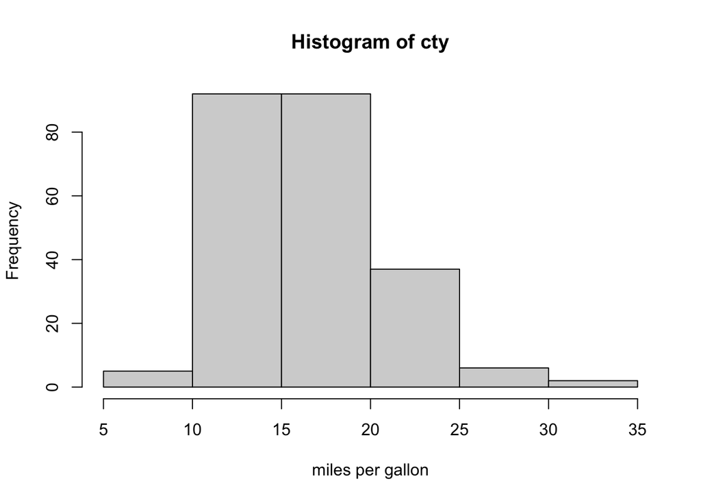

```r
# hist(mpg$cty) this is sufficient
hist(mpg$cty, main = 'Histogram of cty', xlab = 'miles per gallon')
```

In general, some main “embellishments” that work in base R:

- main: the title of the graph
- ylab/xlab: the y and x labels
- ylim/xlim: the limits of the y/x axis. Note that they take in a vector with two numbers that signify the lower/upper limits. e.g. xlim = c(0, 100)

### pie

We may want to understand the distribution of car types using a pie chart. We first need to count how many instances of each type of car is present. There’s a funciton in dplyr called count that does this.

```r
car_types = mpg %>% count(class)
print(car_types)
```

```
## # A tibble: 7 x 2
##   class          n
##   <chr>      <int>
## 1 2seater        5
## 2 compact       47
## 3 midsize       41
## 4 minivan       11
## 5 pickup        33
## 6 subcompact    35
## 7 suv           62
```

Note that under the hood, this is the real function being run: **mpg %>% group_by(class) %>% summarize(counts = n())** i.e. first group by class, and then do a count for each class, with n() being the function for count

Then we can call up a pie chart. The format here is pie(counts of the car types, (optional)labels of car types, (optional)radius of the chart)

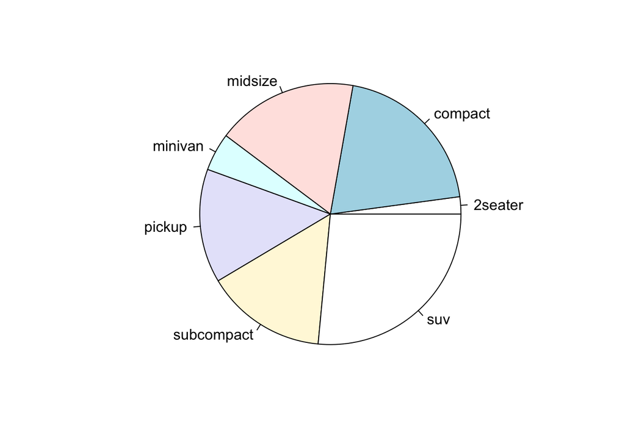

```r
pie(car_types$n, labels = car_types$class, radius = 1)
```

While base R does offer a variety of different types of plots (i.e. line, hist, scatter, etc), the amount of customization is limited. Furthermore, the syntax/pre-treatment required can get complicated especially when we try to have multiple components in the same graph (e.g. line charts with multiple lines). This prompts us to seek for a new way of plotting.

# ggplot

## What is ggplot?

In short, it’s a plotting library that allows for more beautiful and complex plots than the default options in R. Below are some of the fundamental components of a ggplot:

- ggplot() creates an empty coordinate graph. The idea is for you to add layers of graphs.
- Every function in ggplot2 takes a *mapping* argument, which is always paired with *aes(x,y)*.
- **Aesthetic** = visual property of objects in the plot; *color, alpha, size, shape*
- **Facets** = subplots
- **Geom** = the geometrical object that a plot uses to represent data (e.g. bar, line)

*Code template*:

```r
ggplot(data = <DATA>) +
  <GEOM_FUNCTION>(
     mapping = aes(<MAPPINGS>),
     stat = <STAT>,
     position = <POSITION>
  ) +
  <COORDINATE_FUNCTION> +
  <FACET_FUNCTION>
```

## Aesthetics

```r
# Import libraries
library(ggplot2)
mpg # included in ggplot2
```

```
## # A tibble: 234 x 11
##    manufacturer model    displ  year   cyl trans   drv     cty   hwy fl    class
##    <chr>        <chr>    <dbl> <int> <int> <chr>   <chr> <int> <int> <chr> <chr>
##  1 audi         a4         1.8  1999     4 auto(l… f        18    29 p     comp…
##  2 audi         a4         1.8  1999     4 manual… f        21    29 p     comp…
##  3 audi         a4         2    2008     4 manual… f        20    31 p     comp…
##  4 audi         a4         2    2008     4 auto(a… f        21    30 p     comp…
##  5 audi         a4         2.8  1999     6 auto(l… f        16    26 p     comp…
##  6 audi         a4         2.8  1999     6 manual… f        18    26 p     comp…
##  7 audi         a4         3.1  2008     6 auto(a… f        18    27 p     comp…
##  8 audi         a4 quat…   1.8  1999     4 manual… 4        18    26 p     comp…
##  9 audi         a4 quat…   1.8  1999     4 auto(l… 4        16    25 p     comp…
## 10 audi         a4 quat…   2    2008     4 manual… 4        20    28 p     comp…
## # … with 224 more rows
```

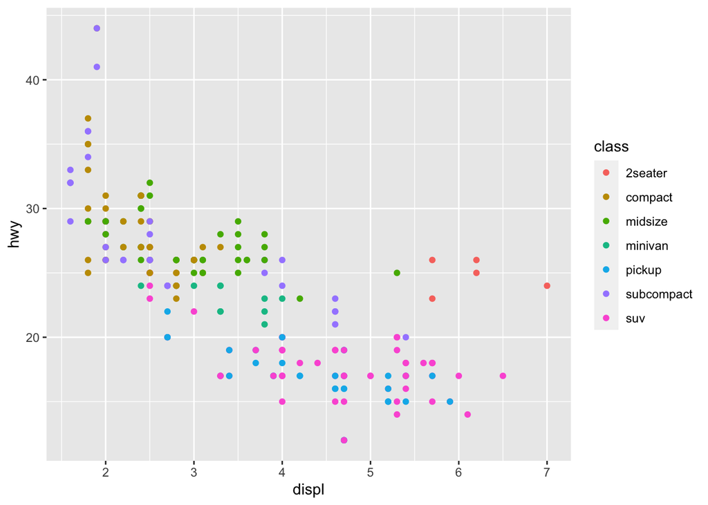

```r
# Here, we map the aesthetic "color" to the variable "class"
ggplot(data = mpg) +
  geom_point(mapping = aes(x=displ, y=hwy, color=class))
```

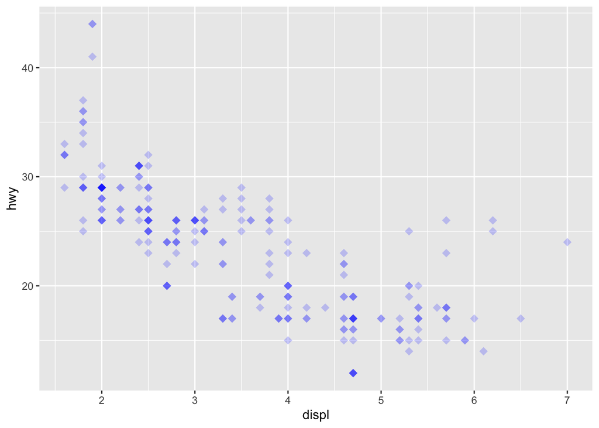

```r
# Outside of aes(), the arguments are applied to the entire plot
ggplot(data = mpg) +
  geom_point(mapping = aes(x=displ, y=hwy),
             color='blue', alpha=0.2, size=3, shape=18)
```